# Section 4 Homework Solutions

**Exercise 1**. Answers will vary.

**Exercise 2**.

Fitting linear model: fy_gpa ~ sat_v + hs_gpa + sex

|  | Estimate | Std. Error | t value | Pr(>\|t\|) |
| --- | --- | --- | --- | --- |
| **(Intercept)** | -0.3927 | 0.1627 | -2.414 | 0.01602 |
| **sat_v** | 0.01988 | 0.002852 | 6.968 | 6.733e-12 |
| **hs_gpa** | 0.6021 | 0.04326 | 13.92 | 1.391e-39 |
| **sexmale** | -0.0785 | 0.04398 | -1.785 | 0.07466 |

1. Write the fitted regression equation with the three predictors.

$$\hat{Y} = -0.3927 + 0.0199 sat_v + 0.6021 hs_{gpa} + -0.0785 sex_{ind}$$

2. 0.312 points.
3. 0.1613 points.
4. 0.2716 points.
5. 0.2483
6. The average error in predicting first year GPA for a model with SAT verbal, High school GPA, and sex as predictors is 0.4335 points.
7. The model without math SAT score because the mean absolute error is slightly lower.
8. Answers here will vary but if you use the analysis to argue **against** the math SAT, you would probably mention the lower mean absolute error in predicting first-year GPA at the college without math SAT in the model. If you use the analysis to argue **for** the math SAT, you might question whether a model with math SAT but without verbal SAT might be better (and that therefore, verbal SAT should be the one that is dropped first).

**Exercise 3**.

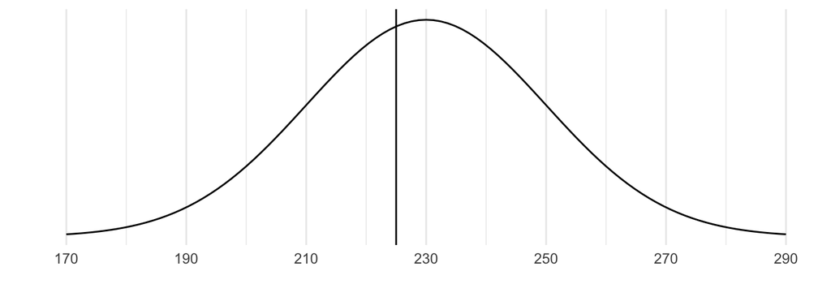

2. Z = -0.25
3. Our time to finish the race is 0.25 standard deviations below the mean race time.
4. 0.4013

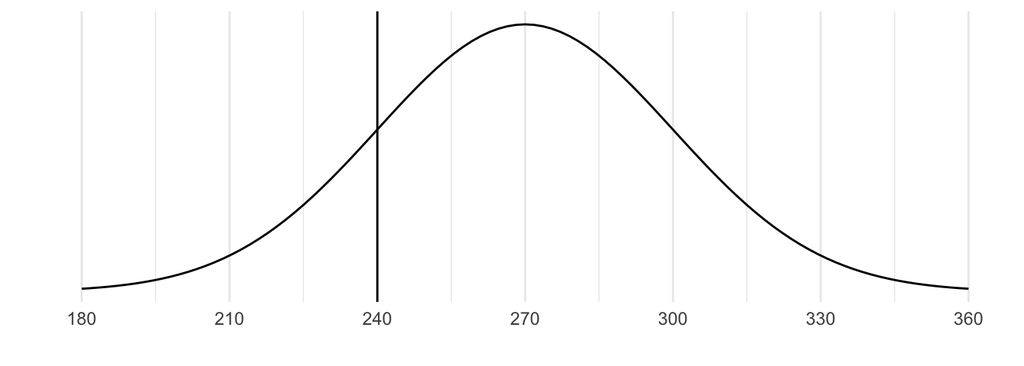

6. Z = -1
7. Race B’s time was more “unusual” because the time is more standard deviations away from the mean time. (Or, Race B’s time was more unusual because the z-score for this race was further from 0).

**Exercise 4**.

Friend A: 1

Friend B: -1.6

**Exercise 5**.

1. Obtain a list of all faculty members and randomly select a certain number (perhaps 50) of them to survey.
2. Ask the faculty members that you know or are familiar with to complete the survey.
3. Send an email to all faculty, asking them to respond to the survey.
4. Force all faculty members to fill out your survey. This is probably not possible, as some faculty members might refuse or might be hard to track down.

**Exercise 6**.

Perhaps only the faculty members who have very strong feelings about diversity and its role in education will respond to the survey while faculty members who do not feel as strongly about the topic would not take the time to respond.

**Exercise 7**.

1. The gardener could lay the 50 pots out in her gardening area, and randomly select 25 of the pots to use the new fertilizer. The other 25 pots would get the old fertilizer. She would then wait an appropriate amount of time and measure the growth on the tomato plants.
2. Answers will vary but one possible confounding variable is the amount of sunlight each plant receives. This variable would be confounding if, for example, (1) the northern half receives more sun so that sunlight is associated with the type of fertilizer (so sunlight is associated with the explanatory variable) AND (2) amount of sunlight is also associated with plant growth (so sunlight is associated with the response).

**Exercise 8**.

1. All students at SLU.
2. $p =$ the proportion of all SLU students who are right-handed.
3. $\hat{p} =$ 0.916.
4. Can make this argument either way. I would argue it probably is representative because, though it is a convenience sample, students who choose not to take STAT 113 probably have similar handedness characteristics as students who choose to take STAT 113.

**Exercise 9**.

1. Sampling variability means that, for different samples of 20 trees, the proportion that are taller than 40 feet will change from one sample of 20 trees to another sample of 20 trees to another sample, etc.

**Exercise 10**.

1. Sampling variability means that, different samples of 150 toddlers can yield different sample proportions that have a peanut allergy.